# SEB task

Juras Lukaševičius

2024-06-19

This task was completed for the **Quantitative Analyst in Credit Risk Model Validation** position in **SEB**. The solution, alongside a description of results and code, are provided in [this repository](https://github.com/SailorGeorge/SEB--Juras-Lukasevicius). The task was completed by **Juras Lukaševičius** using *R Studio*.

You can read this code on the *.html* file to use hyperlinks.

Thanks for reading!

### Table of contents

1. Task outline
2. Data manipulation
3. Data visualization
4. Modelling

### Task outline

Complete the task described in this e-mail. All three parts could be done independent of each other. You are free to choose which task to perform in detail and which one to use in order to demonstrate basic skills. Choose software which is convenient for you (*R*, *Python*, *SAS*, *Tableau*, …). Please provide description of results and codes as well (GitHub/GitLab or e-mail). If you have any questions, do not hesitate to contact.

**Data manipulation task**

Demonstrate your ability to:

- select random subsample of data set;
- filter desired rows using simple and more complex conditions;
- drop unnecessary variables, rename some variables;
- calculate summarizing statistics (for full sample and by categorical variables as well);
- create new variables using simple transformation and custom functions;
- order data set by several variables.

**Data visualization task**

In order to understand the data, please visualize it. You are free to select the scope, types of plots, etc.

**Modelling task** (with response variable *y*)

- Perform a logistic regression to obtain the predicted probability that a customer has subscribed for a term deposit.
- Use continuous variables and dummy variables created for categorical columns. Not necessarily all variables provided in the data sample should be used.
- Evaluate model goodness of fit and predictive ability. If needed, data set could be split into training and test sets.

### Data manipulation

Before starting the three given tasks, I load the testing and full data sets into *R*. I also load the libraries which will be later used while working on the data.

```r
 dt <- read.table("bank.csv", header = TRUE, sep=";")
 d <- read.table("bank-full.csv", header = TRUE, sep=";")

 head(dt)
```

```
##   age         job marital education default balance housing loan  contact day
## 1  30  unemployed married   primary      no    1787      no   no cellular  19
## 2  33    services married secondary      no    4789     yes  yes cellular  11
## 3  35  management  single  tertiary      no    1350     yes   no cellular  16
## 4  30  management married  tertiary      no    1476     yes  yes  unknown   3
## 5  59 blue-collar married secondary      no       0     yes   no  unknown   5
## 6  35  management  single  tertiary      no     747      no   no cellular  23
##   month duration campaign pdays previous poutcome  y
## 1   oct       79        1    -1        0  unknown no
## 2   may      220        1   339        4  failure no
## 3   apr      185        1   330        1  failure no
## 4   jun      199        4    -1        0  unknown no
## 5   may      226        1    -1        0  unknown no
## 6   feb      141        2   176        3  failure no
```

```r
 library(dplyr)   # For data manipulation
 library(ggplot2) # For data visualization
 library(pROC)    # For modelling (ROC and AUC)
```

**Select a random subsample of data set**

To collect a random subsample from a dataset, I use the function `sample()` . Before generating, I set a custom seed to replicate the sample selection on every initialization. `n` shows the number of rows in the sampled data.

```r
set.seed(42)
n <- 200

dt_s <- dt[sample(nrow(dt), n),] # Subsample of data set
head(dt_s)
```

```
##      age         job  marital education default balance housing loan  contact
## 2609  58     retired  married secondary      no      11      no   no cellular
## 4069  30 blue-collar   single secondary      no    6900      no   no cellular
## 2369  35    services  married secondary      no     195     yes   no cellular
## 1098  45  management divorced  tertiary      no    2096      no   no cellular
## 1252  44      admin.  married secondary      no    2403     yes   no cellular
## 634   83     retired  married secondary      no       0      no   no cellular
##      day month duration campaign pdays previous poutcome  y
## 2609  11   aug      270        1    -1        0  unknown no
## 4069  21   nov      816        1    -1        0  unknown no
## 2369  17   apr      203        1    -1        0  unknown no
## 1098  21   nov      127        1   100        2  failure no
## 1252  28   jan      180        2    -1        0  unknown no
## 634   18   mar      140       10    -1        0  unknown no
```

**Filter desired rows using simple and more complex conditions**

First I will complete a simple filtering by selecting rows with `single` marital status. I will apply this to the sampled data set, simply selecting rows in which the variable `marital` is equal to the value `single`.

```r
head(dt_s[dt_s$marital == "single",])
```

```
##      age         job marital education default balance housing loan   contact
## 4069  30 blue-collar  single secondary      no    6900      no   no  cellular
## 356   30    services  single secondary      no     209     yes   no   unknown
## 4261  50   housemaid  single   unknown      no       0      no   no telephone
## 1903  34  technician  single secondary      no     318      no  yes  cellular
## 3944  45    services  single secondary      no    1757     yes   no  cellular
## 481   37  management  single   unknown      no     715     yes   no   unknown
##      day month duration campaign pdays previous poutcome  y
## 4069  21   nov      816        1    -1        0  unknown no
## 356    6   may       30        2    -1        0  unknown no
## 4261  28   jul      118        8    -1        0  unknown no
## 1903  25   jul      239        5    -1        0  unknown no
## 3944  20   apr     1010        3   326        1    other no
## 481   20   may      247        2    -1        0  unknown no
```

For a more complex filtering, I will select rows with `single` marital status and balance between $1000$ and $5000$.

```r
head(dt_s[dt_s$marital == "single" & dt_s$balance >= 1000 & dt_s$balance <= 5000,])
```

```
##      age         job marital education default balance housing loan   contact
## 3944  45    services  single secondary      no    1757     yes   no  cellular
## 982   28 blue-collar  single secondary      no    3412     yes   no  cellular
## 1353  23     student  single secondary      no    1021      no   no telephone
## 1537  32  technician  single secondary      no    2979      no   no  cellular
## 4407  35  unemployed  single secondary      no    2116     yes   no  cellular
## 2859  33  management  single secondary      no    1558     yes   no  cellular
##      day month duration campaign pdays previous poutcome  y
## 3944  20   apr     1010        3   326        1    other no
## 982   15   may       22        4    -1        0  unknown no
## 1353  19   jun       79        9    -1        0  unknown no
## 1537  25   may      156        1    -1        0  unknown no
## 4407  13   may      409        2    -1        0  unknown no
## 2859  17   apr       97        1    -1        0  unknown no
```

**Drop unnecessary variables, rename some variables**

I will drop the date variables and rename the `marital` and `education` variables into their shortened versions `mar` and `edu`.

```r
dt_s <- subset(dt_s, select = -c(day, month))
dt_s <- dt_s %>%
       rename("edu" = "education", "mar" = "marital")

head(dt_s)
```

```
##      age         job      mar       edu default balance housing loan  contact
## 2609  58     retired  married secondary      no      11      no   no cellular
## 4069  30 blue-collar   single secondary      no    6900      no   no cellular
## 2369  35    services  married secondary      no     195     yes   no cellular
## 1098  45  management divorced  tertiary      no    2096      no   no cellular
## 1252  44      admin.  married secondary      no    2403     yes   no cellular
## 634   83     retired  married secondary      no       0      no   no cellular
##      duration campaign pdays previous poutcome  y
## 2609      270        1    -1        0  unknown no
## 4069      816        1    -1        0  unknown no
## 2369      203        1    -1        0  unknown no
## 1098      127        1   100        2  failure no
## 1252      180        2    -1        0  unknown no
## 634       140       10    -1        0  unknown no
```

**Calculate summarizing statistics (for full sample and by categorical variables as well)**

To acquire summarizing statistics for the full sample, I can simply use the function `summary()`. To add summarizing statistics by categorical variables, I can change such variables into factors to see which values are most frequent. For this, I use the `dplyr` conditional transformation `mutate_if()`, which finds categorical variables and converts them into factors.

```r
dt <- dt %>%
  mutate_if(is.character, as.factor)

summary(dt)
```

```
##       age                 job          marital         education    default
##  Min.   :19.00   management :969   divorced: 528   primary  : 678   no :4445
##  1st Qu.:33.00   blue-collar:946   married :2797   secondary:2306   yes:  76
##  Median :39.00   technician :768   single  :1196   tertiary :1350
##  Mean   :41.17   admin.     :478                   unknown  : 187
##  3rd Qu.:49.00   services   :417
##  Max.   :87.00   retired    :230
##                  (Other)    :713
##     balance      housing     loan           contact          day
##  Min.   :-3313   no :1962   no :3830   cellular :2896   Min.   : 1.00
##  1st Qu.:   69   yes:2559   yes: 691   telephone: 301   1st Qu.: 9.00
##  Median :  444                         unknown  :1324   Median :16.00
##  Mean   : 1423                                          Mean   :15.92
##  3rd Qu.: 1480                                          3rd Qu.:21.00
##  Max.   :71188                                          Max.   :31.00
##
##      month         duration       campaign          pdays
##  may    :1398   Min.   :   4   Min.   : 1.000   Min.   : -1.00
##  jul    : 706   1st Qu.: 104   1st Qu.: 1.000   1st Qu.: -1.00
##  aug    : 633   Median : 185   Median : 2.000   Median : -1.00
##  jun    : 531   Mean   : 264   Mean   : 2.794   Mean   : 39.77
##  nov    : 389   3rd Qu.: 329   3rd Qu.: 3.000   3rd Qu.: -1.00
##  apr    : 293   Max.   :3025   Max.   :50.000   Max.   :871.00
##  (Other): 571
##     previous          poutcome      y
##  Min.   : 0.0000   failure: 490   no :4000
##  1st Qu.: 0.0000   other  : 197   yes: 521
##  Median : 0.0000   success: 129
##  Mean   : 0.5426   unknown:3705
##  3rd Qu.: 0.0000
##  Max.   :25.0000
##
```

Here we can find the mean, median, min and max, alongside the first and third quartiles of all numeric variables. For categorical variables, we can see the number of occurrences of each value in the variable. This lets us have a general overlook of the data and helps in finding outliers or missing values in the data. In this scenario, the data set sample has no missing values (no `NA`).

**Create new variables using simple transformation and custom functions**

I’ll create two variables for the data set sample: one will be a simple transformation, which shows if the average yearly balance is above 1000; the other will combine the `month` and `day` variables into one `date` variable using a custom function.

To create the balance variable, I use an `ifelse` condition. Value above a $1000$ are given the category `yes`.

```r
dt <- dt %>%
  mutate(balance1000 = ifelse(balance > 1000, "yes", "no"))
```

To create the `date` variable, I first make a function which changes the `month` value into an integer and combines it with the `day` variable. I use the `paste()` function to add a separator and fit the factorized `month` value into a string. The function with the transformation are provided below.

```r
mon_day <- function(month, day) {

  month_lookup <- c("jan" = "01", "feb" = "02", "mar" = "03",
                    "apr" = "04", "may" = "05", "jun" = "06",
                    "jul" = "07", "aug" = "08", "sep" = "09",
                    "oct" = "10", "nov" = "11", "dec" = "12")

  # This part changes the month into an integer through the lookup vector
  month_num <- sapply(month, function(x) month_lookup[[x]])

  return(paste(month_num, day, sep = "-"))
}

dt <- dt %>%
  mutate(date = mon_day(paste(month), day))

head(dt)
```

```
##   age         job marital education default balance housing loan  contact day
## 1  30  unemployed married   primary      no    1787      no   no cellular  19
## 2  33    services married secondary      no    4789     yes  yes cellular  11
## 3  35  management  single  tertiary      no    1350     yes   no cellular  16
## 4  30  management married  tertiary      no    1476     yes  yes  unknown   3
## 5  59 blue-collar married secondary      no       0     yes   no  unknown   5
## 6  35  management  single  tertiary      no     747      no   no cellular  23
##   month duration campaign pdays previous poutcome  y balance1000  date
## 1   oct       79        1    -1        0  unknown no         yes 10-19
## 2   may      220        1   339        4  failure no         yes 05-11
## 3   apr      185        1   330        1  failure no         yes 04-16
## 4   jun      199        4    -1        0  unknown no         yes  06-3
## 5   may      226        1    -1        0  unknown no          no  05-5
## 6   feb      141        2   176        3  failure no          no 02-23
```

**Order data set by several variables**

I will order the values by the newly created variable `date` and `age` using the function `arrange()`.

```r
dt_ord <- dt %>%
  arrange(date, age)

head(dt_ord)
```

```
##   age           job marital education default balance housing loan   contact
## 1  57       retired married secondary      no    1044      no   no telephone
## 2  28 self-employed  single  tertiary      no    4579      no   no  cellular
## 3  65       unknown married   unknown      no     300      no   no  cellular
## 4  48    unemployed married secondary      no     817      no   no  cellular
## 5  50    management married  tertiary      no      78     yes   no  cellular
## 6  59    technician married   primary      no    4198      no   no  cellular
##   day month duration campaign pdays previous poutcome   y balance1000  date
## 1  11   jan      585        1   192        2  success yes         yes 01-11
## 2  12   jan      409        2    -1        0  unknown yes         yes 01-12
## 3  12   jan      105        1    -1        0  unknown  no          no 01-12
## 4  14   jan      517        1   282        4  success yes          no 01-14
## 5  14   jan      218        3   161        9    other  no          no 01-14
## 6  14   jan      309        1    91       10  success yes         yes 01-14
```

### Data visualization

For the data visualization part, I will make several graphs utilizing both numeric and categorical variables:

Below is the **scatter plot of average yearly balance and age**:

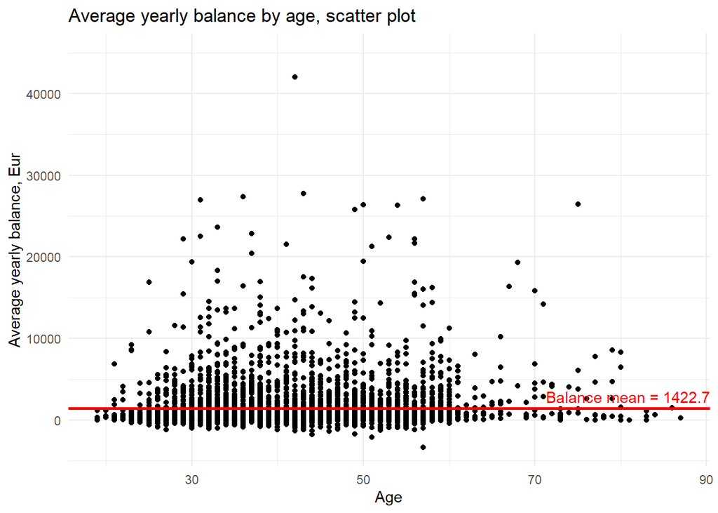

```r
ggplot(dt, aes(x=age, y=balance)) +
  geom_point() +
  ggtitle("Average yearly balance by age, scatter plot") +
  xlim(min(dt$age), max(dt$age)) +
  ylim(min(dt$balance), 45000) + # Lowering y-max, since most values are not
                                 # that high
  geom_hline(yintercept = mean(dt$balance),
             color = "red",
             size=1) +
  annotate("text", x = Inf, y = 5,
           label = "Balance mean = 1422.7",
           hjust = 1, vjust = -1.5, color = "red") +
  labs(x = "Age", y = "Average yearly balance, Eur") +
  theme_minimal()
```

In this graph, we can see that there is no real correlation between average yearly balance and age. We have many similar balances (approximately $1422.7$ Eur) in a wide age demographic, spanning from $19$ to $87$ years of age. The y-axis range has been modified to fit the most common values and hide the outliers.

Below are the **box plots of average yearly balance by education**:

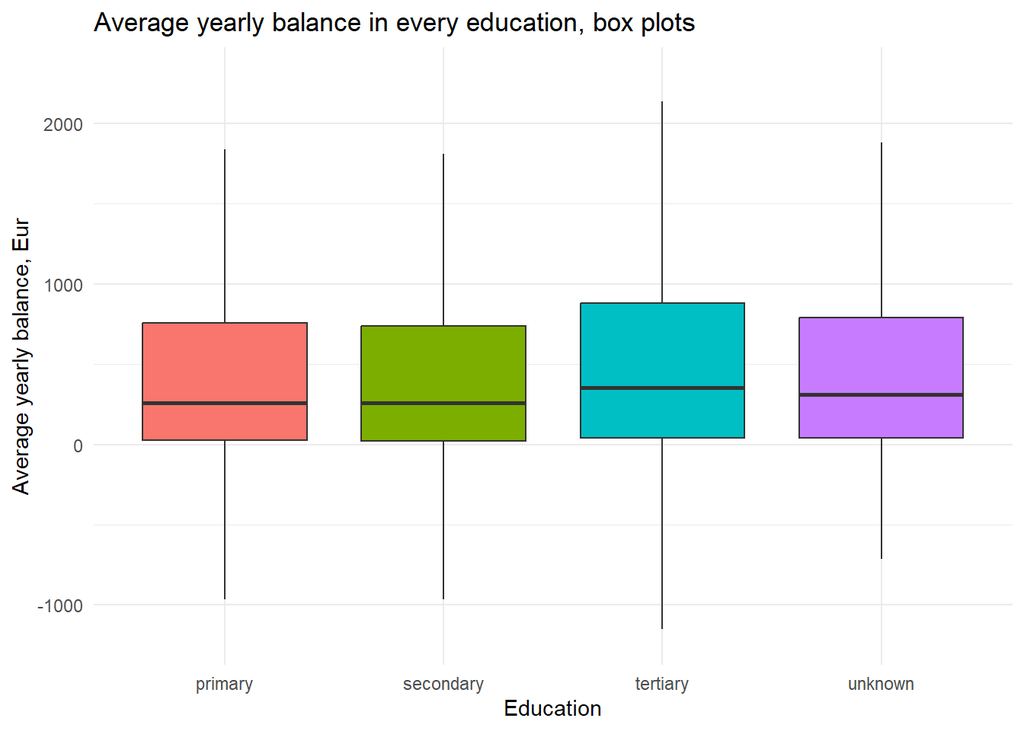

```r
ggplot(dt, aes(x = education, y = balance, fill = education)) +
  geom_boxplot(outlier.shape = NA, outlier.size = 0) +
  ggtitle("Average yearly balance in every education, box plots") +
  labs(x = "Education", y = "Average yearly balance, Eur") +
  ylim(-1200, 2300) +
  theme_minimal() +
  guides(fill = FALSE)
```

These box plots had many outliers with high average yearly balances, which have been hidden for clarity. When analyzing the box plots you can find that the median average yearly balance doesn’t change dramatically depending on your education status. Also, although the minimum - maximum values differ in every single box plot, they are not big enough to make meaningful insights about.

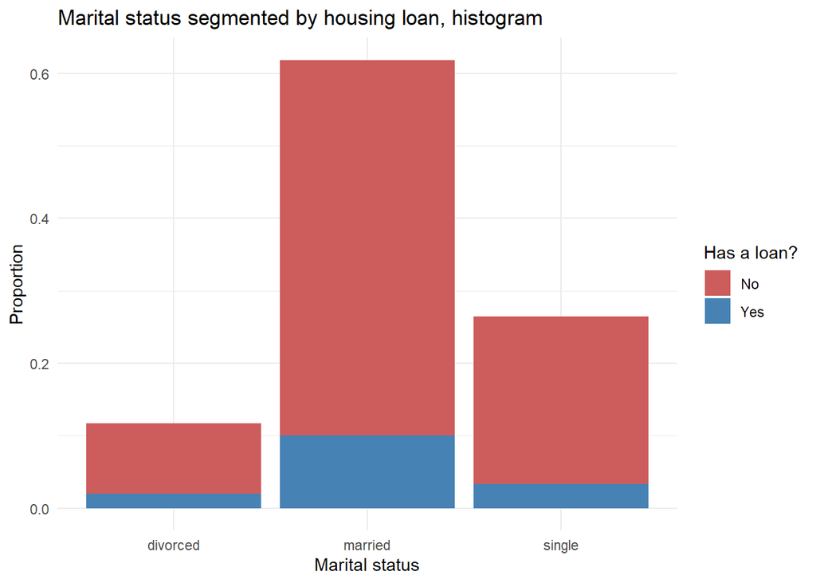

```r
ggplot(dt, aes(x=marital, fill = loan)) +
  geom_bar(aes(y = (..count..)/sum(..count..))) +
  ggtitle("Marital status segmented by housing loan, histogram") +
  labs(x = "Marital status", y = "Proportion") +
  theme_minimal()  +
  scale_fill_manual(
    name = "Has a loan?",
    values = c("indianred", "steelblue"),
    labels = c("No", "Yes")
  )
```

Below is the **pie chart of contact communication type**:

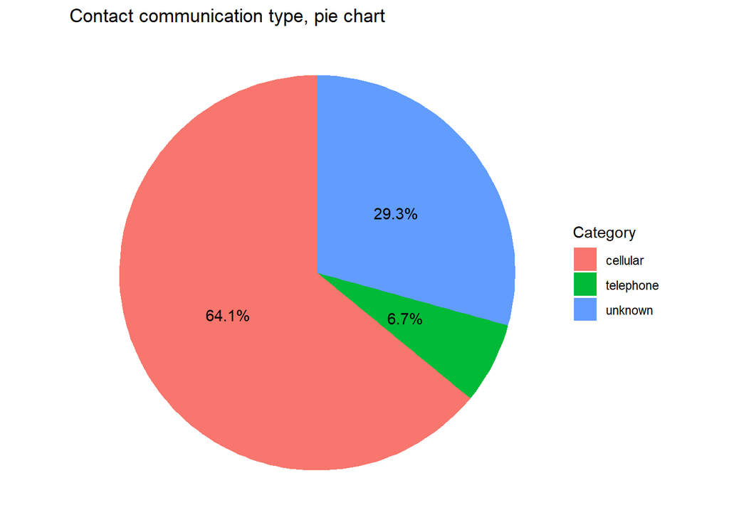

```r
# Here I make an additional summary data set with the column `percentage`,
# which shows the groups proportion.
dt_summary <- dt %>%
  group_by(contact) %>%
  summarise(count = n()) %>%
  ungroup() %>%
  mutate(percentage = count / sum(count) * 100,
         label = paste0(round(percentage, 1), "%"))

ggplot(dt_summary, aes(x = "", y = count, fill = contact)) +
  geom_bar(width = 1, stat = "identity") +
  coord_polar(theta = "y") +
  labs(title = "Contact communication type, pie chart", fill = "Category") +
  theme_void() +
  geom_text(aes(label = label), position = position_stack(vjust = 0.5))
```

This simple pie chart shows the proportion of contact made by communication type. Here we can see that more than half of the contact is made by cellular, almost a third is unknown and just a small proportion is by telephone.

Below is the **line chart of average yearly balance by last month of contact**:

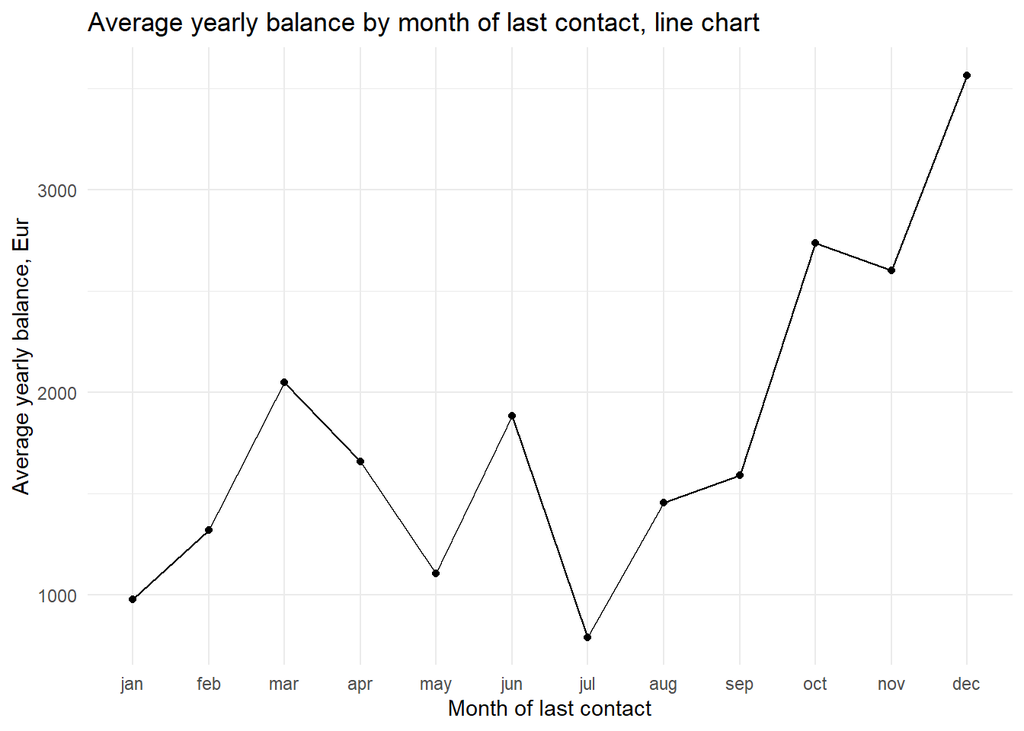

```r
# Here I make an additional summary data set with the column `balance`,
# which shows average balance by month. The mutate function is used to order
# the months from January to December.
dt_summary <- dt %>%
  group_by(month) %>%
  summarise(avg_balance = mean(balance)) %>%
  ungroup() %>%
  mutate(month = factor(month, levels = c("jan", "feb", "mar",
                                          "apr", "may", "jun",
                                          "jul", "aug", "sep",
                                          "oct", "nov", "dec")))

ggplot(dt_summary, aes(x = month, y = avg_balance, group = 1)) +
  geom_line() +  # Line plot
  geom_point() +  # Add points at each month
  labs(title = "Average yearly balance by month of last contact, line chart",
       x = "Month of last contact", y = "Average yearly balance, Eur") +  # Add titles and labels
  theme_minimal()  # Minimal theme
```

### Modelling

In this part, I will complete the modelling task. I rephrased the task as follows:

**Perform a logistic regression to obtain the predicted probability that a customer has subscribed for a term deposit** using relevant **continuous variables and dummy variables created for categorical columns**. The model will be created using a training set and later I will use the testing set to **evaluate model goodness of fit and predictive ability**.

First we will load all the variables to the model and pick out the significant variables. This can be done when inspecting their p-values. I will remove the `date` variable, since it has too many factors and its values are representative of the `month` and `day` columns.

I will choose the variables using the sample data set `dt` and then I’ll use the full data set `d` to check how the model performs.

```r
dt_prep <- subset(dt, select=-c(date))

head(dt_prep)
```

```
##   age         job marital education default balance housing loan  contact day
## 1  30  unemployed married   primary      no    1787      no   no cellular  19
## 2  33    services married secondary      no    4789     yes  yes cellular  11
## 3  35  management  single  tertiary      no    1350     yes   no cellular  16
## 4  30  management married  tertiary      no    1476     yes  yes  unknown   3
## 5  59 blue-collar married secondary      no       0     yes   no  unknown   5
## 6  35  management  single  tertiary      no     747      no   no cellular  23
##   month duration campaign pdays previous poutcome  y balance1000
## 1   oct       79        1    -1        0  unknown no         yes
## 2   may      220        1   339        4  failure no         yes
## 3   apr      185        1   330        1  failure no         yes
## 4   jun      199        4    -1        0  unknown no         yes
## 5   may      226        1    -1        0  unknown no          no
## 6   feb      141        2   176        3  failure no          no
```

```r
glm <- glm(y ~ .,data = dt_prep, family = 'binomial')

summary(glm)
```

```
##
## Call:
## glm(formula = y ~ ., family = "binomial", data = dt_prep)
##
## Coefficients:
##                      Estimate Std. Error z value Pr(>|z|)
## (Intercept)        -2.469e+00  6.044e-01  -4.086 4.39e-05 ***
## age                -5.844e-03  7.166e-03  -0.816 0.414773
## jobblue-collar     -4.246e-01  2.420e-01  -1.754 0.079381 .
## jobentrepreneur    -2.339e-01  3.805e-01  -0.615 0.538715
## jobhousemaid       -2.981e-01  4.164e-01  -0.716 0.474101
## jobmanagement      -9.941e-02  2.410e-01  -0.413 0.679922
## jobretired          6.420e-01  3.118e-01   2.059 0.039462 *
## jobself-employed   -2.083e-01  3.531e-01  -0.590 0.555242
## jobservices        -1.638e-01  2.732e-01  -0.600 0.548694
## jobstudent          3.287e-01  3.767e-01   0.872 0.382990
## jobtechnician      -2.083e-01  2.299e-01  -0.906 0.364845
## jobunemployed      -6.446e-01  4.215e-01  -1.529 0.126218
## jobunknown          5.317e-01  5.738e-01   0.927 0.354053
## maritalmarried     -4.831e-01  1.750e-01  -2.761 0.005765 **
## maritalsingle      -3.308e-01  2.048e-01  -1.615 0.106279
## educationsecondary  6.276e-02  2.028e-01   0.310 0.756908
## educationtertiary   2.813e-01  2.348e-01   1.198 0.230981
## educationunknown   -4.606e-01  3.585e-01  -1.285 0.198913
## defaultyes          6.593e-01  4.343e-01   1.518 0.128999
## balance            -5.023e-05  2.723e-05  -1.844 0.065134 .
## housingyes         -2.720e-01  1.383e-01  -1.966 0.049242 *
## loanyes            -6.078e-01  2.005e-01  -3.031 0.002434 **
## contacttelephone   -9.355e-02  2.337e-01  -0.400 0.688982
## contactunknown     -1.404e+00  2.282e-01  -6.154 7.56e-10 ***
## day                 1.620e-02  8.176e-03   1.981 0.047579 *
## monthaug           -2.799e-01  2.503e-01  -1.118 0.263461
## monthdec            6.453e-02  6.520e-01   0.099 0.921160
## monthfeb            1.981e-01  2.947e-01   0.672 0.501530
## monthjan           -1.097e+00  3.853e-01  -2.848 0.004394 **
## monthjul           -7.052e-01  2.505e-01  -2.815 0.004876 **
## monthjun            5.266e-01  3.012e-01   1.748 0.080449 .
## monthmar            1.469e+00  3.916e-01   3.751 0.000176 ***
## monthmay           -4.783e-01  2.343e-01  -2.041 0.041247 *
## monthnov           -8.942e-01  2.753e-01  -3.248 0.001162 **
## monthoct            1.392e+00  3.312e-01   4.204 2.62e-05 ***
## monthsep            7.061e-01  4.110e-01   1.718 0.085832 .
## duration            4.221e-03  2.026e-04  20.836  < 2e-16 ***
## campaign           -7.086e-02  2.826e-02  -2.508 0.012151 *
## pdays              -8.364e-05  9.921e-04  -0.084 0.932812
## previous           -6.425e-03  3.784e-02  -0.170 0.865183
## poutcomeother       4.907e-01  2.707e-01   1.813 0.069869 .
## poutcomesuccess     2.410e+00  2.774e-01   8.688  < 2e-16 ***
## poutcomeunknown    -1.254e-01  3.194e-01  -0.392 0.694732
## balance1000yes      5.309e-01  1.472e-01   3.608 0.000309 ***
## ---
## Signif. codes:  0 '***' 0.001 '**' 0.01 '*' 0.05 '.' 0.1 ' ' 1
##
## (Dispersion parameter for binomial family taken to be 1)
##
##     Null deviance: 3231.0  on 4520  degrees of freedom
## Residual deviance: 2160.2  on 4477  degrees of freedom
## AIC: 2248.2
##
## Number of Fisher Scoring iterations: 6
```

Now we will create the complete model using these variables on the full data set. For this we will also split the data into a $80$-$20$ training-testing split. The training set will be used to prepare the model and the testing set will be used to assess its performance.

```r
# --------------------------------------------------------------------------- #
# These are the same transformations as previously applied to the data sample #

d <- d %>%
  mutate_if(is.character, as.factor)

d <- d %>%
  mutate(balance1000 = ifelse(balance > 1000, "yes", "no"))

d <- d %>%
  mutate(date = mon_day(paste(month), day))

# --------------------------------------------------------------------------- #

d_mod <- subset(d, select=-c(date)) # Removed `date` variable

set.seed(42)
train_indices <- sample(1:nrow(d_mod), size = 0.8 * nrow(d_mod))

train_data <- d_mod[train_indices, ] # Training data
test_data <- d_mod[-train_indices, ] # Testing data
```

```r
glm2 <- glm(y ~ 1 + job + marital + contact + loan + month +
               duration + campaign + poutcome + balance1000,
               data = train_data, family = 'binomial')

glm_test <- glm(y ~ .,
                data = train_data, family = 'binomial')

summary(glm2)         # Selected model AIC
```

```
##
## Call:
## glm(formula = y ~ 1 + job + marital + contact + loan + month +
##     duration + campaign + poutcome + balance1000, family = "binomial",
##     data = train_data)
##
## Coefficients:
##                    Estimate Std. Error z value Pr(>|z|)
## (Intercept)      -2.669e+00  1.125e-01 -23.719  < 2e-16 ***
## jobblue-collar   -4.804e-01  7.752e-02  -6.197 5.74e-10 ***
## jobentrepreneur  -5.049e-01  1.445e-01  -3.494 0.000477 ***
## jobhousemaid     -4.378e-01  1.457e-01  -3.006 0.002650 **
## jobmanagement    -2.147e-02  7.055e-02  -0.304 0.760892
## jobretired        3.758e-01  9.394e-02   4.001 6.32e-05 ***
## jobself-employed -1.848e-01  1.205e-01  -1.534 0.124965
## jobservices      -3.210e-01  9.364e-02  -3.428 0.000607 ***
## jobstudent        5.436e-01  1.168e-01   4.654 3.25e-06 ***
## jobtechnician    -2.061e-01  7.610e-02  -2.709 0.006754 **
## jobunemployed    -9.798e-02  1.217e-01  -0.805 0.420736
## jobunknown       -1.847e-01  2.576e-01  -0.717 0.473427
## maritalmarried   -2.131e-01  6.514e-02  -3.271 0.001071 **
## maritalsingle     1.200e-01  6.991e-02   1.716 0.086179 .
## contacttelephone -7.901e-02  8.167e-02  -0.967 0.333342
## contactunknown   -1.582e+00  8.053e-02 -19.645  < 2e-16 ***
## loanyes          -4.649e-01  6.657e-02  -6.984 2.87e-12 ***
## monthaug         -4.816e-01  8.410e-02  -5.726 1.03e-08 ***
## monthdec          8.349e-01  1.913e-01   4.364 1.28e-05 ***
## monthfeb         -3.193e-02  9.154e-02  -0.349 0.727238
## monthjan         -1.037e+00  1.347e-01  -7.699 1.37e-14 ***
## monthjul         -6.777e-01  8.455e-02  -8.015 1.10e-15 ***
## monthjun          5.255e-01  9.961e-02   5.276 1.32e-07 ***
## monthmar          1.690e+00  1.318e-01  12.827  < 2e-16 ***
## monthmay         -5.702e-01  7.900e-02  -7.218 5.28e-13 ***
## monthnov         -7.843e-01  9.167e-02  -8.555  < 2e-16 ***
## monthoct          1.016e+00  1.183e-01   8.588  < 2e-16 ***
## monthsep          1.015e+00  1.324e-01   7.666 1.78e-14 ***
## duration          4.141e-03  7.138e-05  58.010  < 2e-16 ***
## campaign         -8.215e-02  1.102e-02  -7.456 8.91e-14 ***
## poutcomeother     1.325e-01  1.009e-01   1.313 0.189042
## poutcomesuccess   2.442e+00  8.872e-02  27.519  < 2e-16 ***
## poutcomeunknown  -1.457e-02  6.349e-02  -0.229 0.818529
## balance1000yes    2.620e-01  4.203e-02   6.234 4.54e-10 ***
## ---
## Signif. codes:  0 '***' 0.001 '**' 0.01 '*' 0.05 '.' 0.1 ' ' 1
##
## (Dispersion parameter for binomial family taken to be 1)
##
##     Null deviance: 26055  on 36167  degrees of freedom
## Residual deviance: 17439  on 36134  degrees of freedom
## AIC: 17507
##
## Number of Fisher Scoring iterations: 6
```

```r
summary(glm_test)$aic # All variables model AIC
```

```
## [1] 17302.17
```

After selecting our variables, we can see that the AIC value, which is a measure of the relative quality of a statistical model for a given data set, rises from $17302.17$ to $17507$. Although this isn’t a huge gap, it does shows that the general model with all variables is better, but not by a lot.

Finally, to evaluate model goodness of fit and predictive ability, we will create a confusion matrix and check the models predictive capabilities.

```r
glm_pred <- predict(glm2, test_data, type = 'response')

conf_matrix <- table(as.numeric(glm_pred>0.5), test_data$y)
rownames(conf_matrix) <- c("no", "yes")
cat("Confusion matrix:")
```

```
## Confusion matrix:
```

```r
print(conf_matrix)
```

```
##
##         no  yes
##   no  7777  709
##   yes  196  361
```

```r
accuracy <- sum(diag(conf_matrix)) / sum(conf_matrix)
cat("Accuracy:", accuracy, "\n")
```

```
## Accuracy: 0.8999226
```

```r
precision <- diag(conf_matrix) / rowSums(conf_matrix)
cat("Precision:", precision, "\n")
```

```
## Precision: 0.9164506 0.6481149
```

```r
recall <- diag(conf_matrix) / colSums(conf_matrix)
cat("Recall:", recall, "\n")
```

```
## Recall: 0.975417 0.3373832
```

```r
f1 <- 2 * (precision * recall) / (precision + recall)
cat("F1-score:", f1, "\n")
```

```
## F1-score: 0.9450149 0.4437615
```

The confusion matrix shows us how many values have been predicted correctly. Since the confusion matrix itself is difficult to interpret, we can utilize metrics like accuracy, precision, recall and F1 to assess the model’s utility.

After the confusion matrix, I will additionally explore the ROC curve and its AUC value, to inspect model accuracy. To draw an ROC curve I use the library `pROC`.

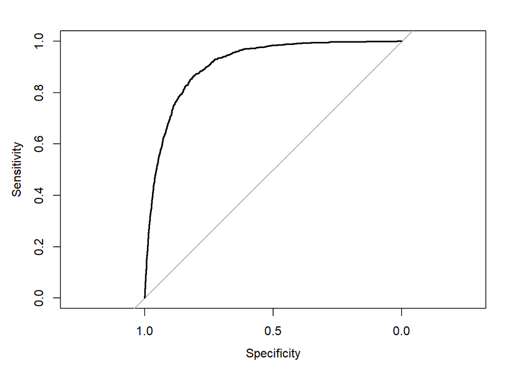

```r
roc_curve <- roc(test_data$y, glm_pred)
plot(roc_curve)
```

```r
auc(roc_curve)
```

```
## Area under the curve: 0.9081
```

From this curve and, more notably, from the high AUC (area under curve) value of $90.8\%$ we can see that the model performs well under the testing data and shows high accuracy.

### That is all. Thank you for reading!